# Lab 6

Author

Nathan Weitershausen

```r
library(dplyr)
library(ggplot2)
library(tidytext)
library(readr)
library(tidyverse)
library(forcats)

mt_samples <- read_csv("https://raw.githubusercontent.com/USCbiostats/data-science-data/master/00_mtsamples/mtsamples.csv")
```

```
──────────────────────────────────────────────────────── Delimiter: "," chr
(5): description, medical_specialty, sample_name, transcription, keywords dbl
(1): ...1
```

```r
mt_samples <- mt_samples |>
  select(description, medical_specialty, transcription)

head(mt_samples)
```

```
# A tibble: 6 × 3
  description                                    medical_specialty transcription
  <chr>                                          <chr>             <chr>
1 A 23-year-old white female presents with comp… Allergy / Immuno… "SUBJECTIVE:…
2 Consult for laparoscopic gastric bypass.       Bariatrics        "PAST MEDICA…
3 Consult for laparoscopic gastric bypass.       Bariatrics        "HISTORY OF …
4 2-D M-Mode. Doppler.                           Cardiovascular /… "2-D M-MODE:…
5 2-D Echocardiogram                             Cardiovascular /… "1.  The lef…
6 Morbid obesity.  Laparoscopic antecolic anteg… Bariatrics        "PREOPERATIV…
```

# Question 1: What specialties do we have?

Use the count() function from dplyr to figure out how many different categories we have in the data. Are these categories related? Overlapping? Evenly distributed?

```r
mt_samples |>
  count(medical_specialty, sort = TRUE)
```

```
# A tibble: 40 × 2
   medical_specialty                 n
   <chr>                         <int>
 1 Surgery                        1103
 2 Consult - History and Phy.      516
 3 Cardiovascular / Pulmonary      372
 4 Orthopedic                      355
 5 Radiology                       273
 6 General Medicine                259
 7 Gastroenterology                230
 8 Neurology                       223
 9 SOAP / Chart / Progress Notes   166
10 Obstetrics / Gynecology         160
# ℹ 30 more rows
```

```r
mt_samples |>
  arrange(description)
```

```
# A tibble: 4,999 × 3
   description                                   medical_specialty transcription
   <chr>                                         <chr>             <chr>
 1 1+ year, black female for initial evaluation… Pediatrics - Neo… SUBJECTIVE:,…
 2 1+ year, black female for initial evaluation… Dermatology       SUBJECTIVE:,…
 3 1-month-old for a healthy checkup - Well chi… Pediatrics - Neo… SUBJECTIVE:,…
 4 1-month-old for a healthy checkup - Well chi… Consult - Histor… SUBJECTIVE:,…
 5 1-year well child check.                      Pediatrics - Neo… SUBJECTIVE:,…
 6 1-year well child check.                      Consult - Histor… SUBJECTIVE:,…
 7 1-year-old male who comes in with a cough an… General Medicine  SUBJECTIVE:,…
 8 1-year-old male who comes in with a cough an… Consult - Histor… SUBJECTIVE:,…
 9 11-year-old female.  History of congestion, … General Medicine  SUBJECTIVE:,…
10 11-year-old female.  History of congestion, … Consult - Histor… SUBJECTIVE:,…
# ℹ 4,989 more rows
```

## Summary

There are 40 categories/medical specialties in the data. There is some overlap, as viewing mt_samples and arranging by the description column will reveal that some reports are listed under two or more medical specialties. The data does not seem to be evenly distributed, as some specialties, like “Speech - Language,” have less than 10 reports and other specialties have hundreds of reports.

# Question 2

Tokenize the the words in the transcription column. Count the number of times each token appears. Visualize the top 20 most frequent words. Explain what we see from this result. Does it makes sense? What insights (if any) do we get?

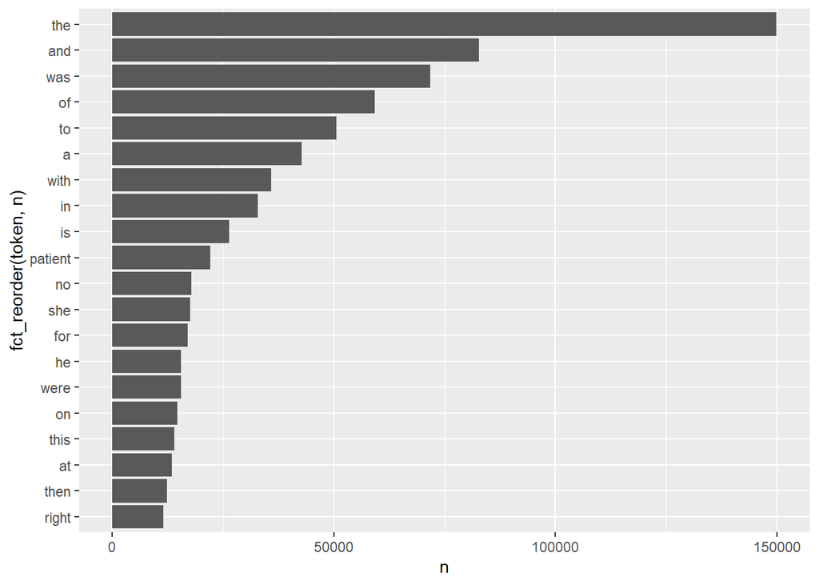

```r
mt_samples |>
  unnest_tokens(token, transcription) |>
  count(token, sort = TRUE) |>
  top_n(20, n) |>
  ggplot(aes(n, fct_reorder(token,n))) + geom_col ()
```

## Summary

Based on the list, the top 20 most frequent words are stop words and “patient.” This makes sense given stop words are commonly used words and “patient” would be a common word given the context of the data. Because these are stop words, they do not give much context/insights into the data.

# Question 3

Re-do the visualization but remove stop words before making it. Bonus points if you remove numbers as well. What do we see now that we have removed stop words? Does it give us a better idea of what the text is about?

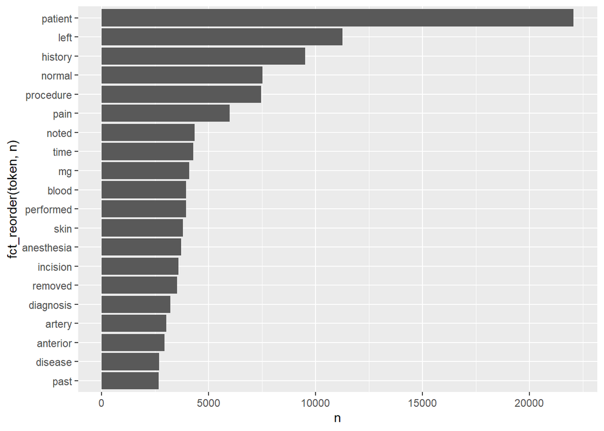

```r
mt_samples |>
  unnest_tokens(token, transcription) |>
  anti_join(stop_words, by = c("token" = "word")) |>
  filter(!grepl("[0-9]", token)) |>
  count(token, sort=TRUE) |>
  top_n(20,n) |>
  ggplot(aes(n, fct_reorder(token,n))) + geom_col ()
```

## Summary

This list provides more context and reveals more “medical” terms, such as “procedure” and “diagnosis.” This list makes more sense given the context of the data and appears to not have any leftover stop words.

# Question 4

Repeat question 2, but this time tokenize into bi-grams. How does the result change if you look at tri-grams?

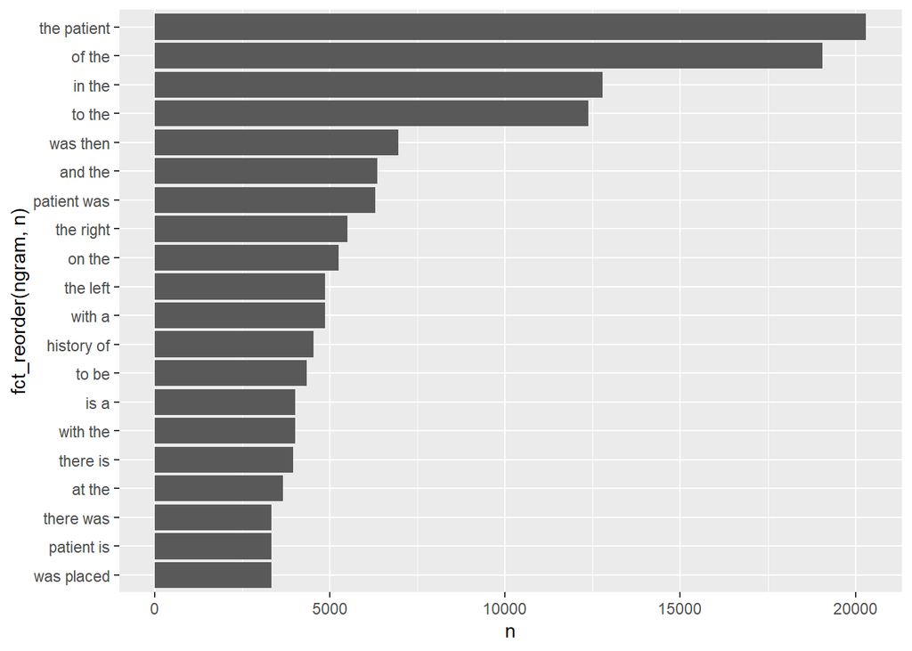

```r
mt_samples |>
  unnest_ngrams(ngram, transcription, n=2) |>
  count(ngram, sort= TRUE) |>
  top_n(20, n) |>
  ggplot(aes(n, fct_reorder(ngram,n))) + geom_col ()
```

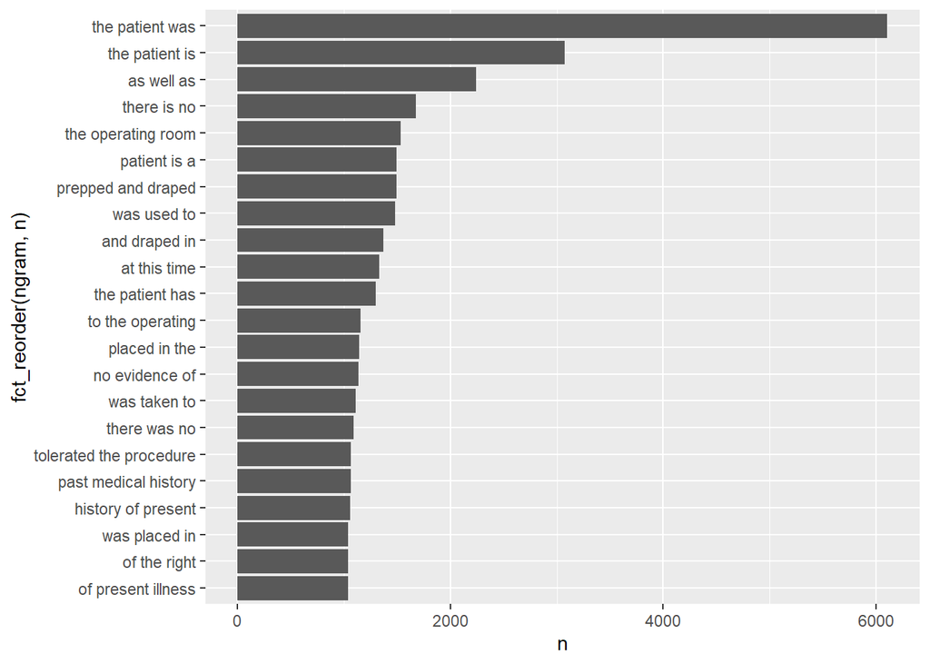

```r
mt_samples |>
  unnest_ngrams(ngram, transcription, n=3) |>
  count(ngram, sort= TRUE) |>
  top_n(20, n) |>
  ggplot(aes(n, fct_reorder(ngram,n))) + geom_col ()
```

## Summary

Tokenizing the data into bi-grams gives a list of mainly combined stop words, for example, “of the” and “with a.” Tokenizing the data into tri-grams gives a list that provides more context about the data, for example, “the operating room” and “past medical history,” however, stop words combinations still appear. There is also a three-way tie for the 20th spot on the list, which is why there are 22 results rather than just 20.

# Question 5

Using the results you got from Question 4, pick a word and count the words that appear before and after it.

```r
#Words that appear before "patient"
mt_samples |>
  unnest_ngrams(ngram, transcription, n=2) |>
  separate(ngram, into = c("word1", "word2"), sep = " ") |>
  select(word1, word2) |>
  filter(word2 == "patient") |>
  count(word1, sort= TRUE) |>
  top_n(20, n)
```

```
# A tibble: 20 × 2
   word1           n
   <chr>       <int>
 1 the         20307
 2 this          470
 3 history       101
 4 a              67
 5 and            47
 6 procedure      32
 7 female         26
 8 with           25
 9 use            24
10 old            23
11 sample         23
12 male           22
13 new            19
14 general        16
15 illness        16
16 plan           16
17 indications    15
18 to             15
19 your           15
20 allergies      14
```

```r
#Words that appear after "patient"
mt_samples |>
  unnest_ngrams(ngram, transcription, n=2) |>
  separate(ngram, into = c("word1", "word2"), sep = " ") |>
  select(word1, word2) |>
  filter(word1 == "patient") |>
  count(word2, sort= TRUE) |>
  top_n(20, n)
```

```
# A tibble: 20 × 2
   word2          n
   <chr>      <int>
 1 was         6293
 2 is          3332
 3 has         1417
 4 tolerated    994
 5 had          888
 6 will         616
 7 denies       552
 8 and          377
 9 states       363
10 does         334
11 also         301
12 in           246
13 did          232
14 to           215
15 the          200
16 underwent    180
17 received     160
18 reports      155
19 with         141
20 understood   113
```

## Summary

The first list represents the top 20 most frequent words that appear before “patient” and the second list represents the top 20 most frequent words that appear after “patient.”

# Question 6

Which words are most used in each of the specialties? You can use group_by() and top_n() from dplyr to have the calculations be done within each specialty. Remember to remove stop words. What are the 5 most-used words for each specialty?

```r
mt_samples |>
  unnest_tokens(token, transcription) |>
  group_by(medical_specialty)|>
  anti_join(stop_words, by = c("token" = "word")) |>
  filter(!grepl("[0-9]", token)) |>
  count(token, sort=TRUE) |>
  top_n(5,n) |>
  arrange(medical_specialty, desc(n))
```

```
# A tibble: 210 × 3
# Groups:   medical_specialty [40]
   medical_specialty    token         n
   <chr>                <chr>     <int>
 1 Allergy / Immunology history      38
 2 Allergy / Immunology noted        23
 3 Allergy / Immunology patient      22
 4 Allergy / Immunology allergies    21
 5 Allergy / Immunology nasal        13
 6 Allergy / Immunology past         13
 7 Autopsy              left         83
 8 Autopsy              inch         59
 9 Autopsy              neck         55
10 Autopsy              anterior     47
# ℹ 200 more rows
```

## Summary

The top five most used words for each specialty are listed in this table. Some lists contain ties, so that is why more than five words appear for some specialties and not others.

# Question 7

I wanted to see how different specialties referred to participants/patients/subjects/people, as I believe that will show the nature of the article/description, providing even more context.

```r
people_terms <- "^(patient|participant|subject|patients|participants|subjects|volunteer|volunteers|client|clinets)$"

mt_samples |>
  unnest_tokens(token, transcription) |>
  group_by(medical_specialty)|>
  filter(!grepl("[0-9]", token), grepl(people_terms, token)) |>
  count(token, sort= TRUE) |>
  arrange(medical_specialty, desc(n))
```

```
# A tibble: 83 × 3
# Groups:   medical_specialty [40]
   medical_specialty          token          n
   <chr>                      <chr>      <int>
 1 Allergy / Immunology       patient       22
 2 Allergy / Immunology       patients       1
 3 Autopsy                    patient       18
 4 Bariatrics                 patient       62
 5 Bariatrics                 patients       1
 6 Cardiovascular / Pulmonary patient     1516
 7 Cardiovascular / Pulmonary patients       2
 8 Cardiovascular / Pulmonary subjects       1
 9 Chiropractic               patient       85
10 Chiropractic               volunteers     1
# ℹ 73 more rows
```

## Summary

From what I see, “patient” or “patients” seem to be the most common way these articles/descriptions refer to people, which makes sense given the graph in Question 3. By just combing the table, there aren’t really any other words that stand out to me, as most have less than 10 counts. However, I do notice that some specialties use a variety of words, like “Chiropractic” and “Psychiatry/Psychology,” while some specialties only use “patient” or “patients,” like “ENT -Otolaryngology” and “Urology.” If I were to expand the list of “people_terms” to include more words that could describe people, then there could be more variation in the words used.